# BA64036_Assignment1

Ruthvick Bulagakula

2023-09-29

## Introduction

The purpose of this assignment is to set up and use the tools for this course.

## Instructions

1. Install the ISLR library using the install.packages() command. Call the library using the library(ISLR) command to ensure that the library is correctly installed (10% of total points)

**Calling Installed Library**

```r
# If i use install.packages() command rmd file is failing to knit.
# so, i've removed install.packages() command

library(ISLR) # Using Library to call installed ISLR library
```

2. Create a new R-Notebook (.Rmd) file. In the first code chunk, call the ISLR library and then print the summary of the Carseats dataset. How many observations (rows) this dataset contains? (15% of total points)

**Using Careseats Dataset**

```r
summary(Carseats) # Using Summary function to get descriptive statistics of Carseats dataset
```

```
##      Sales          CompPrice       Income        Advertising
##  Min.   : 0.000   Min.   : 77   Min.   : 21.00   Min.   : 0.000
##  1st Qu.: 5.390   1st Qu.:115   1st Qu.: 42.75   1st Qu.: 0.000
##  Median : 7.490   Median :125   Median : 69.00   Median : 5.000
##  Mean   : 7.496   Mean   :125   Mean   : 68.66   Mean   : 6.635
##  3rd Qu.: 9.320   3rd Qu.:135   3rd Qu.: 91.00   3rd Qu.:12.000
##  Max.   :16.270   Max.   :175   Max.   :120.00   Max.   :29.000
##    Population        Price        ShelveLoc        Age          Education
##  Min.   : 10.0   Min.   : 24.0   Bad   : 96   Min.   :25.00   Min.   :10.0
##  1st Qu.:139.0   1st Qu.:100.0   Good  : 85   1st Qu.:39.75   1st Qu.:12.0
##  Median :272.0   Median :117.0   Medium:219   Median :54.50   Median :14.0
##  Mean   :264.8   Mean   :115.8                Mean   :53.32   Mean   :13.9
##  3rd Qu.:398.5   3rd Qu.:131.0                3rd Qu.:66.00   3rd Qu.:16.0
##  Max.   :509.0   Max.   :191.0                Max.   :80.00   Max.   :18.0
##  Urban       US
##  No :118   No :142
##  Yes:282   Yes:258
##
##
##
##
```

**No.of Observations in carseats dataset**

```r
nrow(Carseats) # Using nrow function to get no of rows in Carsearts dataset
```

```
## [1] 400
```

3. Using the summary statistics shown above, what is maximum value of the advertising attribute? (15% of total points)

**Maximum Values of the advertising**

```r
max(Carseats$Advertising) # Using max function to get maximum value of advertising
```

```
## [1] 29
```

4. Calculate the IQR of the Price attribute. (15% of total points)

**IQR for Price**

```r
IQR(Carseats$Price) # Using IQR function to get Interquartile Range for Price
```

```
## [1] 31
```

5. Plot the Sales against Price. What do you see in there? Calculate the correlation of the two attributes. What does the sign of the correlation coefficient suggest? (15% of total points)

**Plotting Sales againt Price**

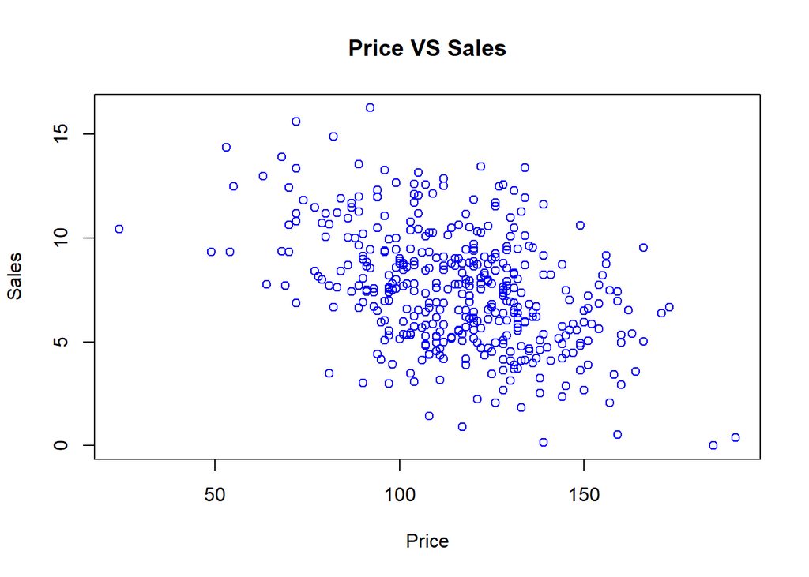

```r
# Using plot function to get scatterplot for Price againt Sales
plot(Carseats$Price, Carseats$Sales, xlab = "Price", ylab = "Sales", main = "Price VS Sales", col = "Blue")
```

**Correlation coefficient for price and sales**

```r
cor(Carseats$Price, Carseats$Sales) # Using cor function to Price and Sales correlation
```

```
## [1] -0.4449507
```